# Explore Distributions (40pt)

```python
# Import packages
import pandas as pd
import numpy as np
import matplotlib.pyplot as plt
import os
os.getcwd()
```

```
'/home/jovyan/PS'
```

```
1. (1pt) Choose your sample size S. 10,000 is a good number.
```

```python
# Choose 10000 as the sample size
S = 10000
```

```
2. (12pt) Explore the shape of the distribution: draw Srandom numbers from LN(0,0.2) (i.e. μ=0 and σ=0.2), LN(0,0.5)and LN(0,1.68). Display all these samples on a histogram while labeling clearly which one is which one. Do the histograms in two ways:
a) linear-linear scale, and
b) log-linear (xis log and yis linear), you just do histogram of logxinstead of x(you can also set log scale in matplotlib, but the bin widths will look weird).
Comment the shape of histograms: do they look skewed? Do they look normal?
```

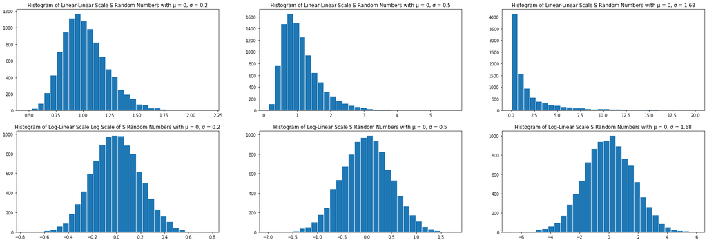

```python
# Draw S random numbers from LN(0,0.2), LN(0,0.5), and LN(0,1.68) and take their log values
LN1 = np.random.lognormal(0, 0.2, size = S)
LN2 = np.random.lognormal(0, 0.5, size = S)
LN3 = np.random.lognormal(0, 1.68, size = S)
LN1_log = np.log(LN1)
LN2_log = np.log(LN2)
LN3_log = np.log(LN3)
# Although the question suggests to do these on one plot, the pattern is not visually apparent. Proffessor Ott suggested to visualize these on six different plots
# The visualization combined six different graphs into one for better comparison and visualization
fig, ax = plt.subplots(2, 3, figsize = (30, 10))
ax[0, 0].hist(LN1, bins = 30, edgecolor = 'w')
ax[0, 0].set_title('Histogram of Linear-Linear Scale S Random Numbers with μ = 0, σ = 0.2')
ax[0, 1].hist(LN2, bins = 30, edgecolor = 'w')
ax[0, 1].set_title('Histogram of Linear-Linear Scale S Random Numbers with μ = 0, σ = 0.5')
# Range is set for better visualization
ax[0, 2].hist(LN3, bins = 30, edgecolor = 'w', range = (0, 20))
ax[0, 2].set_title('Histogram of Linear-Linear Scale S Random Numbers with μ = 0, σ = 1.68')
ax[1, 0].hist(LN1_log, bins=30, edgecolor = 'w')
ax[1, 0].set_title('Histogram of Log-Linear Scale Log Scale of S Random Numbers with μ = 0, σ = 0.2')
ax[1, 1].hist(LN2_log, bins = 30, edgecolor = 'w')
ax[1, 1].set_title('Histogram of Log-Linear Scale S Random Numbers with μ = 0, σ = 0.5')
ax[1, 2].hist(LN3_log, bins = 30, edgecolor = 'w')
ax[1, 2].set_title('Histogram of Log-Linear Scale S Random Numbers with μ = 0, σ = 1.68')
```

After looking at the histograms, it appears that the S random numbers with μ = 0, σ = 0.2 looks overall normally distributed, it does appear to skew right a bit but it is not very clear on the histogram. For histograms of S random numbers with μ = 0, σ = 0.5 and σ = 1.68, they are heavily right skewed. All three linear-linear plots are possibly log-normal. For the histograms of log-linear S random numbers, all three appear to be normally distributed.

```
3. (5pt) Look at the histograms and tell-what do you think, which one describes the least unequal distribution, and which one the most unequal distribution?
```

```
4. (10pt) Compute sample means and variance (just use np.mean and such functions), and compare those with what you get using the corresponding theoretical formulas (2) and (3). Are these similar?
```

```python
# Compute the theoretical values
LN1_EV = np.exp(0 + 1/2 * 0.2**2)
LN2_EV = np.exp(0 + 1/2 * 0.5**2)
LN3_EV = np.exp(0 + 1/2 * 1.68**2)
LN1_var = np.exp(2 * 0 + 0.2**2) * (np.exp(0.2**2) - 1)
LN2_var = np.exp(2 * 0 + 0.5**2) * (np.exp(0.5**2) - 1)
LN3_var = np.exp(2 * 0 + 1.68**2) * (np.exp(1.68**2) - 1)
# Compute the sample means and variances of the different numbers
print('The sample mean of S Random Numbers with μ = 0, σ = 0.2 is:', np.mean(LN1), ', and the sample variance is:', np.var(LN1))
print('The expected value of S Random Numbers with μ = 0, σ = 0.2 is:', LN1_EV, ', and the variance is:', LN1_var)
print()
print('The sample mean of S Random Numbers with μ = 0, σ = 0.5 is:', np.mean(LN2), ', and the sample variance is:', np.var(LN2))
print('The expected value of S Random Numbers with μ = 0, σ = 0.5 is:', LN2_EV, ', and the variance is:', LN2_var)
print()
print('The sample mean of S Random Numbers with μ = 0, σ = 1.68 is:', np.mean(LN3), ', and the sample variance is:', np.var(LN3))
print('The expected value of S Random Numbers with μ = 0, σ = 1.68 is:', LN3_EV, ', and the variance is:', LN3_var)
```

```
The sample mean of S Random Numbers with μ = 0, σ = 0.2 is: 1.0192122829980212 , and the sample variance is: 0.043189941290445406
The expected value of S Random Numbers with μ = 0, σ = 0.2 is: 1.0202013400267558 , and the variance is: 0.04247629348257031

The sample mean of S Random Numbers with μ = 0, σ = 0.5 is: 1.1200217805979371 , and the sample variance is: 0.3529626023513398
The expected value of S Random Numbers with μ = 0, σ = 0.5 is: 1.1331484530668263 , and the variance is: 0.3646958540123865

The sample mean of S Random Numbers with μ = 0, σ = 1.68 is: 4.070632898371721 , and the sample variance is: 184.21864582835218
The expected value of S Random Numbers with μ = 0, σ = 1.68 is: 4.1008735008239405 , and the variance is: 265.99982369887033
```

After computing the theoretical means and variances and comparing those with the sample means and variances, I realize that the sample means of μ = 0, σ = 0.2 and μ = 0, σ = 0.5 are similar to their theoretical values. The one with μ = 0, σ = 0.2 appears to have a smaller difference between the sample values and theoretical values than the one with μ = 0, σ = 0.5. The sample mean and variance is not so similar for μ = 0, σ = 1.68. There is a huge gap between the sample variance and the theoretical variance. This makes me suspect that as the σ increases, the theoretical values are going to be less similar to the sample values.

```
5. (6pt) Compute the 20/80 ratio for all the three distributions. You can re-use your code from PS2.
Hint: the answers should be similar to what is in Table 1.7 in lecture notes (page 46 for now)
```

```python
# Compute the 20/80 ratio for LN1
for pct in range(99, 50, -1):
    threshold = np.percentile(LN1, pct)
    sample_1 = LN1
    share = sample_1[sample_1 > threshold].sum()/sample_1.sum()
    if 100 * share > pct:
        print(pct, share)
        break
top_percent = 100 - pct
print('For σ = 0.2:')
print('The top', top_percent, 'owns', share * 100, 'of the total.')
```

```
54 0.5404921021665843
For σ = 0.2:
The top 46 owns 54.04921021665843 of the total.
```

```python
# Compute the 20/80 ratio for LN2
for pct in range(99, 50, -1):
    threshold = np.percentile(LN2, pct)
    sample_2 = LN2
    share = sample_2[sample_2 > threshold].sum()/sample_2.sum()
    if 100 * share > pct:
        print(pct, share)
        break
top_percent = 100 - pct
print('For σ = 0.5:')
print('The top', top_percent, 'owns', share * 100, 'of the total.')
```

```
59 0.6069537486419893
For σ = 0.5:
The top 41 owns 60.695374864198925 of the total.
```

```python
# Compute the 20/80 ratio for LN3
for pct in range(99, 50, -1):
    threshold = np.percentile(LN3, pct)
    sample_3 = LN3
    share = sample_3[sample_3 > threshold].sum()/sample_3.sum()
    if 100 * share > pct:
        print(pct, share)
        break
top_percent = 100 - pct
print('For σ = 1.68:')
print('The top', top_percent, 'owns', share * 100, 'of the total.')
```

```
80 0.8001379292766704
For σ = 1.68:
The top 20 owns 80.01379292766704 of the total.
```

```
6. (6pt) Finally, show similar histograms of all three datasets you analyzed in PS2 (Income, Moon craters, and publications; you can just copy-paste your code from PS2). Do these histograms look like log-normal, or like something else?
```

```python
# Load the three datasets
treatment_data = pd.read_csv('/home/jovyan/PS/data/treatment.csv', sep='\t')
treatment_data = treatment_data['re78'].dropna()
citation_data = pd.read_csv('/home/jovyan/PS/data/mag-30k-citations.csv', sep='\t')
citation_data = citation_data['citations'].dropna()
lunar_data = pd.read_csv('/home/jovyan/PS/data/lunar-impact-craters_v08-2015-09.csv', sep='\t')
lunar_data = lunar_data['7. Radius [m]'].dropna()
```

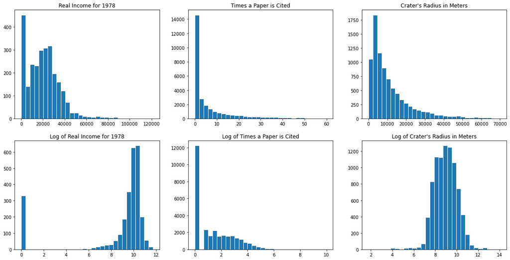

```python
# Copy and paste code from PS2
# Combine all six plots into one figure
fig, ax = plt.subplots(2, 3, figsize = (20, 10))
# Generates six plots that contain the normal and log value of the interested dataframe value
ax[0, 0].hist(treatment_data, bins=30, edgecolor = 'w')
ax[0, 0].set_title('Real Income for 1978')
# Range is set to get a btter visualization
ax[0, 1].hist(citation_data, bins = 30, edgecolor = 'w', range = (0, 60))
ax[0, 1].set_title('Times a Paper is Cited')
ax[0, 2].hist(lunar_data, bins = 30, edgecolor = 'w', range = (0, 70000))
ax[0, 2].set_title('Crater\'s Radius in Meters')
ax[1, 0].hist(np.log(1 + treatment_data), bins=30, edgecolor = 'w')
ax[1, 0].set_title('Log of Real Income for 1978')
ax[1, 1].hist(np.log(1 + citation_data), bins = 30, edgecolor = 'w', range = (0, 10))
ax[1, 1].set_title('Log of Times a Paper is Cited')
ax[1, 2].hist(np.log(1 + lunar_data), bins = 30, edgecolor = 'w')
ax[1, 2].set_title('Log of Crater\'s Radius in Meters')
plt.show()
```

For Income, Moon craters, and publications, all three unscaled graphs look log-normal. For the log scaled graphs, the one for real income appears to be left-skewed, the log scaled of paper citation looks log-normal, and the crater's radius just looks normally distributed.

# Explore Central Limit Theorem (60pt)

```
1. (8pt) Calculate the expected value and variance of this random variable.
Note: these are theoretical values and not related to any samples. If you use functions like mean or var here then you have misunderstood the concepts!
Hint: read lecture notes 1.3.4 (Expected Value and Variance), and Openintro Statistics 3.4 (Random variables), in particular 3.4.2 (Variability). I recommend to use the shortcut formula VarX=EX^2 −(EX)^2.
```

```python
# Calculte the expected value for X
expected_value_X = (0.5) * (-1) + (0.5) * (1)
# Calculate the variance
variance_X = (0.5) * (1) + (0.5) * (1) - (expected_value_X)**2
# Print results
print("Expected value: " + str(expected_value_X))
print("Variance: " + str(variance_X))
```

```
Expected value: 0.0
Variance: 1.0
```

```
2. (1pt) Choose your number of repetitions R. 1000 is a good number but you can also take 10,000 or 100,000 to get smoother histograms.
Note: number of repetitions Ris not the same as sample size Shere. You will create samples of size Sfor Rtimes below. For instance you will create R=1000 times a sample of size S=5. Please understand the difference, it is a fequent source of confusion!
```

```python
# Choose the number of repetitions
R = 1000
```

```
3. (5pt) Create a vector of Rrandom realizations of X. Make a histogram of those. Comment the shape of the histogram.
Note: in this case we have R=1000 repetitions and samples are of size S=1 as we look at individual realizations.
Hint: it takes some tweaking to get nice histograms of discrete distributions. The simplest way is just to make many bars (most of which will be 0) by adding argument bins=100 to plt.hist.
```

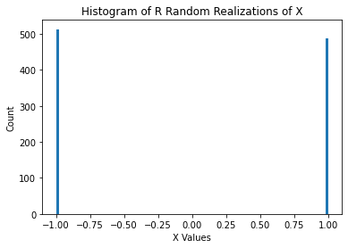

```python
# Create an empty vector
random_X = []
# Add elements in the random_X vector by creating different samples from the RV
for i in range(0, R):
    value_X = np.random.randint(0, 2, size = 1) * 2 - 1
    random_X.append(value_X[0])

# PLot the historgram
Rrealization_plot = plt.hist(random_X, bins = 100)
Rrealization_plot = plt.title('Histogram of R Random Realizations of X')
Rrealization_plot = plt.xlabel('X Values')
Rrealization_plot = plt.ylabel('Count')
plt.show()
```

```
4. (5pt) Compute and report mean and variance of the sample you created (just use np.mean and np.var). NB! Here we talk about sample mean and sample variance. Compare these numbers with the theoretical values computed at question 1 above.
```

```python
# Calculate the mean and variance of 1000 individual random trials of -1, 1
sample_mean = np.mean(random_X)
sample_var = np.var(random_X)

# Print Results
print("Mean: " + str(sample_mean))
print("Variance: " + str(sample_var))
```

```
Mean: -0.026
Variance: 0.9993240000000002
```

Since the sample means is very close to 0, and the sample variance is very close to 1, we can say that the values in this section are very close to the original 50/50 probability.

```
5. (7pt) Now create Rpairs of random realizations of X(i.e. sample size S=2). For each pair, compute its mean. You should have Rmeans. Make the histogram. How does this look like?
Hint: while you can do this using loops, it is more useful to create a R×2 matrix of realizations of X, where each row represents one pair. Thereafter you compute means by rows and you have Rpair means. See python notes numpy statistical functions for an example.
```

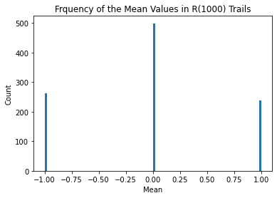

```python
# Make a function to get the mean and the variance for later uses
def get_mean_var(x):
    mean_var = []
    mean_var.append(np.mean(x))
    return mean_var

# Make a function to get the R number of trails of size s of random drawing of 1 and -1
def get_random(s):
    Rpairs = []
    mean_Rpairs = []
    for i in range(0, R):
        current_trial = np.random.randint(0, 2, size = s) * 2 - 1
        Rpairs.append(current_trial)
        Rpairs_mean_var = get_mean_var(current_trial)
        mean_Rpairs.append(Rpairs_mean_var[0])
    return(mean_Rpairs)

# Create Rpairs of random realization of sample size 2 and calcultae mean and variance
mean_R_pairs = get_random(2)

# Plot the results
mean_plot = plt.hist(mean_R_pairs, bins = 100)
mean_plot = plt.title('Frquency of the Mean Values in R(1000) Trails')
mean_plot = plt.xlabel('Mean')
mean_plot = plt.ylabel('Count')
```

From the histogram, we can see that roughly half of the trails out of R trials (1000) have a mean of 0. The rest have means of either -1 or 1. Within the trials with means of -1 and 1, approximately half has the mean of -1 and the other half with a mean of 1. The histogram may suggest a multimodal distribution.

```
6. (5pt) Compute and report mean of the Rpair means, and variance of the means. NB! we talk about sample mean and sample variance again, where sample is your sample of Rpair means.
```

```python
# Compute and print the mean of the Rpaid means and variance of the means
print("Mean of R pair means: " + str(np.mean(mean_R_pairs)))
print("Variance of R pair means: " + str(np.var(mean_R_pairs)))
```

```
Mean of R pair means: -0.025
Variance of R pair means: 0.5003749999999999
```

```
7. (8pt) Compute the expected value and variance of the pair means, i.e. the theoretical concepts. This mirrors what you did in 1.
Compare the theoretical values with the sample values above. Are those fairly similar?
Note that according to CLT, the variance of a pair mean should be just 1/2 of what you got above as for pairs S=2.
```

```python
# Calculate the expected value and variance of pair means
pairs_expected_value = (1/2) * (0) + (1/4) * (-1) + (1/4) * (1)
pairs_expected_var = ((1/4) * (1) + (1/2) * (0) + (1/4) * (1)) - pairs_expected_value**2

# Print the results
print("Expected value of pair means: " + str(pairs_expected_value))
print("Variance of pair means: " + str(pairs_expected_var))
```

```
Expected value of pair means: 0.0
Variance of pair means: 0.5
```

After comparing the theoretical values and the sample values, I realized they are very similar to one another because they have very small differences

```
8. (4pt) Now instead of pairs of random numbers, repeat this with 5-tuples of random numbers (i.e. S=5 random numbers per one repetition, and still R=1000 repetitions in total). Compare the theoretical and sample version of mean and variance of 5-tuples. Are they similar? Do you spot any noticeable differences in the histogram compared to your previous histogram?
```

```
Sample Mean of 5-tuples means: 0.0023999999999999985
Sample Variance of 5-tuples means: 0.20991424
Expected value of pair means: 0.0
Variance of pair means: 0.2
```

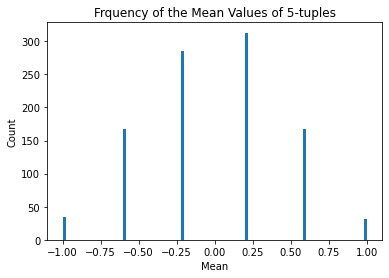

```python
# Get a R vector of S = 5
mean_five_tuples = get_random(5)
# Compute the sample mean and variance
print("Sample Mean of 5-tuples means: " + str(np.mean(mean_five_tuples)))
print("Sample Variance of 5-tuples means: " + str(np.var(mean_five_tuples)))
# Compute the expected value and variance of 5-tuples
# This is done to prove that no matter what tuple size it is, the expected value will always be 0 for this RV
five_tuples_EV = (1/32)*(1) + (1/32)*(-1) + (5/32)*(4/5) + (5/32)*(-4/5) + (10/32)*(1/5) + (10/32)*(-1/5)
five_tuples_var = variance_X / 5
# Print the theoretical results
print("Expected value of pair means: " + str(five_tuples_EV))
print("Variance of pair means: " + str(five_tuples_var))
# Plot the histogram of the 5-tuples means
five_tuples_plot = plt.hist(mean_five_tuples, bins = 100)
five_tuples_plot = plt.title('Frquency of the Mean Values of 5-tuples')
five_tuples_plot = plt.xlabel('Mean')
five_tuples_plot = plt.ylabel('Count')
```

```
9. (3pt) Repeat with 25-tuples... (Including compute the expectation and theoretical variance, and compare those with sample mean, sample variance)
```

```
Sample Mean of 5-tuples means: -0.0010400000000000014
Sample Variance of 5-tuples means: 0.0407157184
Expected value of pair means: 0.0
Variance of pair means: 0.04
```

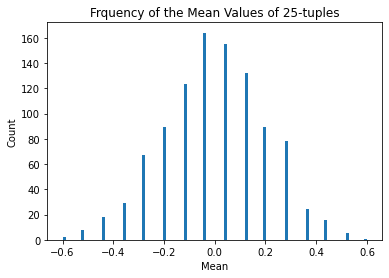

```python
# Get a R vector of S = 25
mean_twenty_five_tuples = get_random(25)
# Compute the sample mean and variance
print("Sample Mean of 5-tuples means: " + str(np.mean(mean_twenty_five_tuples)))
print("Sample Variance of 5-tuples means: " + str(np.var(mean_twenty_five_tuples)))
# Print the theoretical results
print("Expected value of pair means: " + str(five_tuples_EV)) # Because the expected value will always be 0
print("Variance of pair means: " + str(variance_X / 25))
# Plot the histogram of the 5-tuples means
five_tuples_plot = plt.hist(mean_twenty_five_tuples, bins = 100)
five_tuples_plot = plt.title('Frquency of the Mean Values of 25-tuples')
five_tuples_plot = plt.xlabel('Mean')
five_tuples_plot = plt.ylabel('Count')
```

After conducting the 25-tuples, there are even more bars and outcomes on the histogram. The values are more evenly distributed than the last histogram. The sample mean and variance got even closer to the theoretical values.

```
10. (3pt) ... and with 1000-tuples. Do not forget to compare with theoretical results.
```

```
Sample Mean of 5-tuples means: -0.0012880000000000003
Sample Variance of 5-tuples means: 0.000993157056
Expected value of pair means: 0.0
Variance of pair means: 0.001
```

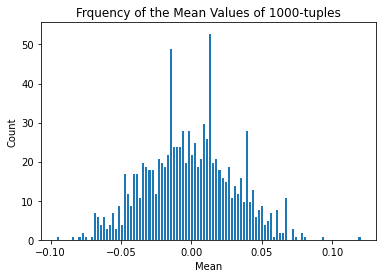

```python
# Get a R vector of S = 1000
mean_thousand_tuples = get_random(1000)
# Compute the sample mean and variance
print("Sample Mean of 5-tuples means: " + str(np.mean(mean_thousand_tuples)))
print("Sample Variance of 5-tuples means: " + str(np.var(mean_thousand_tuples)))
# Print the theoretical results
print("Expected value of pair means: " + str(five_tuples_EV)) # Because the expected value will always be 0
print("Variance of pair means: " + str(variance_X / 1000))
# Plot the histogram of the 5-tuples means
five_tuples_plot = plt.hist(mean_thousand_tuples, bins = 100, edgecolor = 'w')
five_tuples_plot = plt.title('Frquency of the Mean Values of 1000-tuples')
five_tuples_plot = plt.xlabel('Mean')
five_tuples_plot = plt.ylabel('Count')
```

```
11. (3pt) Comment on the tuple size, and how the shape of the histogram changes when the tuple size increases.
```

Based on the different histograms, it appears that as the tuple size increases, the distribution becomes more and more normal and there are more and more possibly mean values.

```
12. (8pt) Explain why do the histograms resemble normal distribution as Sgrows.
In particular, explain what happens when we move from single values S=1 to pairs S=2. Why did two equal peaks turn into a “山”-shaped histogram?
```

When S=1, our random variable X has a 0.5 probability of having a mean of -1 (tails) and a 0.5 probability of having a mean of 1 (heads). When we increase the size from 1 to 2, there are more combinations. We can have head-head, head-tail, tail-head, and tail-tail. In term of numbers, we will have (1, 1), (1, -1), (-1, 1), (-1, -1) and the means of those sets are 1, 0, 0, and -1. This explains why that extra bar is in the middle and makes the equal peaks into a 山 shaped histogram. As we increase the sizes, the combinations of heads and tails also increase and change the possible means, making the distribution more normal.